# Benchmarking: calling cancer cells

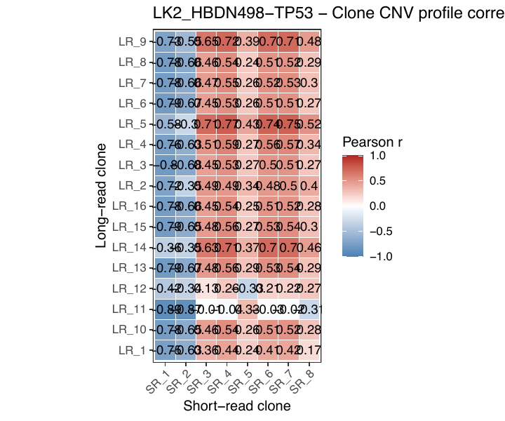

**`LK2_HBDN498-TP53_clone_matched_alluvial.pdf`**

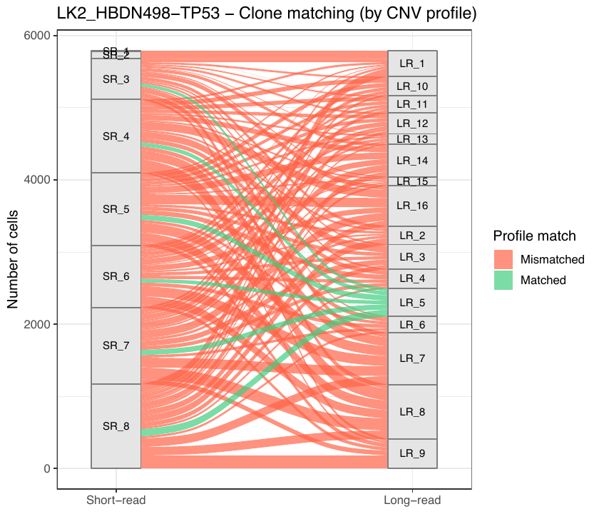

**`LK2_HBDN498-TP53_compartment_alluvial.pdf`**

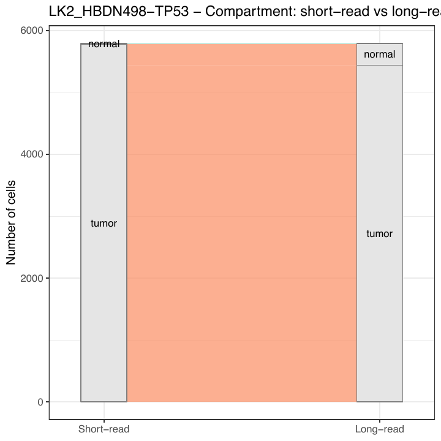

**`LK2_HBDN498-TP53_pCNV_scatter.pdf`**

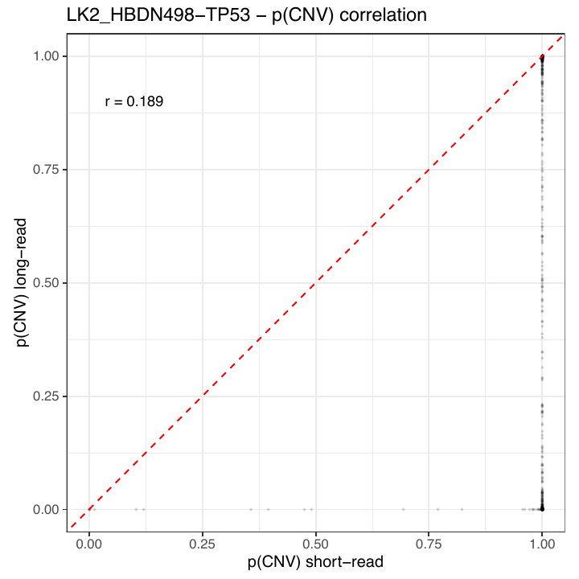

**`LK2_HBDN498-TP53_segments_comparison.pdf`**

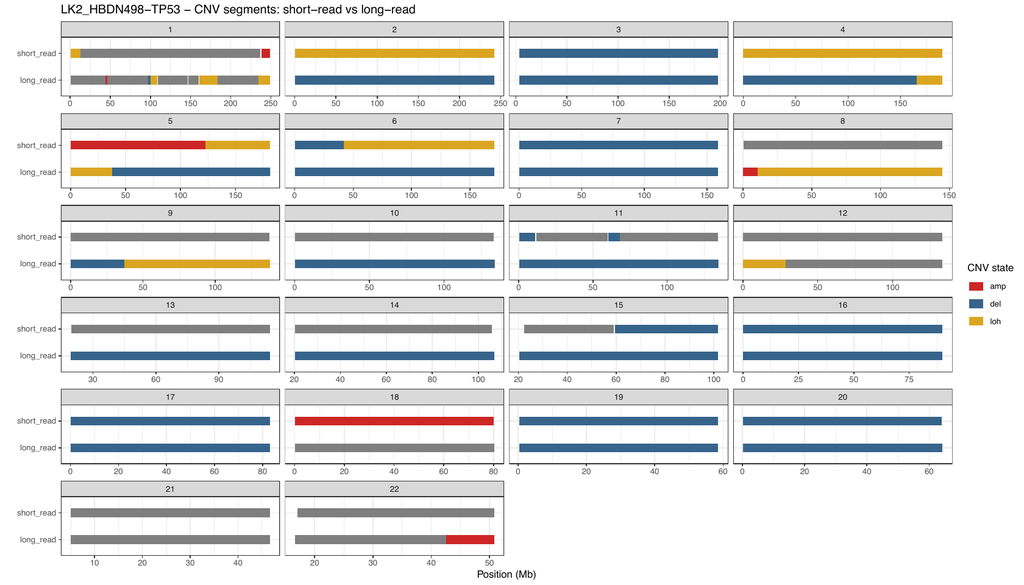

**`01_copykat_call_composition_by_sampleID.pdf`**

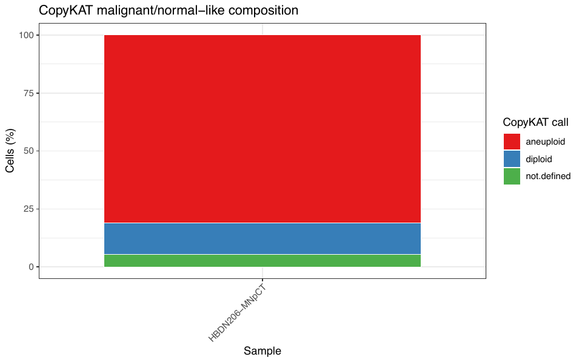

**`02_copykat_calls_on_projected_RNA_UMAP.pdf`**

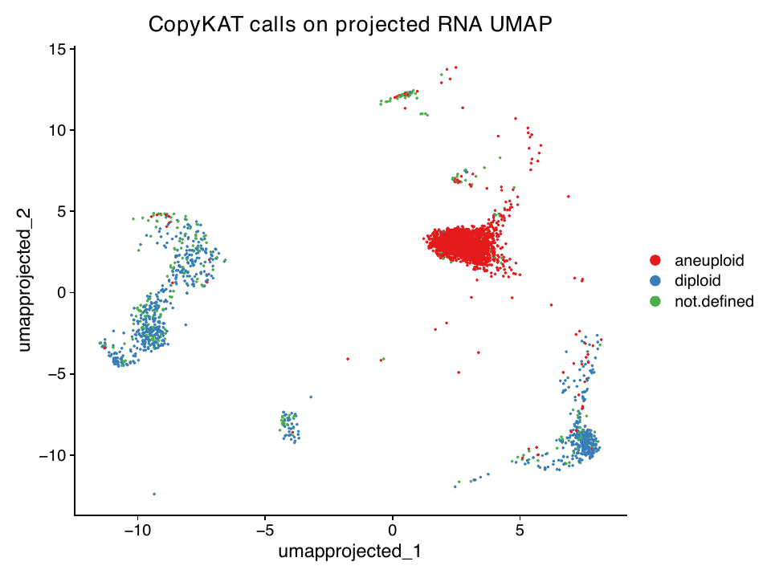

**`02a_copykat_calls_on_projected_RNA_UMAP.pdf`**

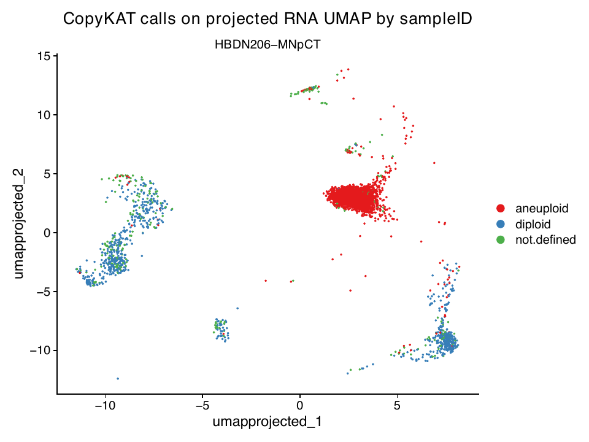

**`03_copykat_by_BoneMarrowMap_broad_celltype.pdf`**

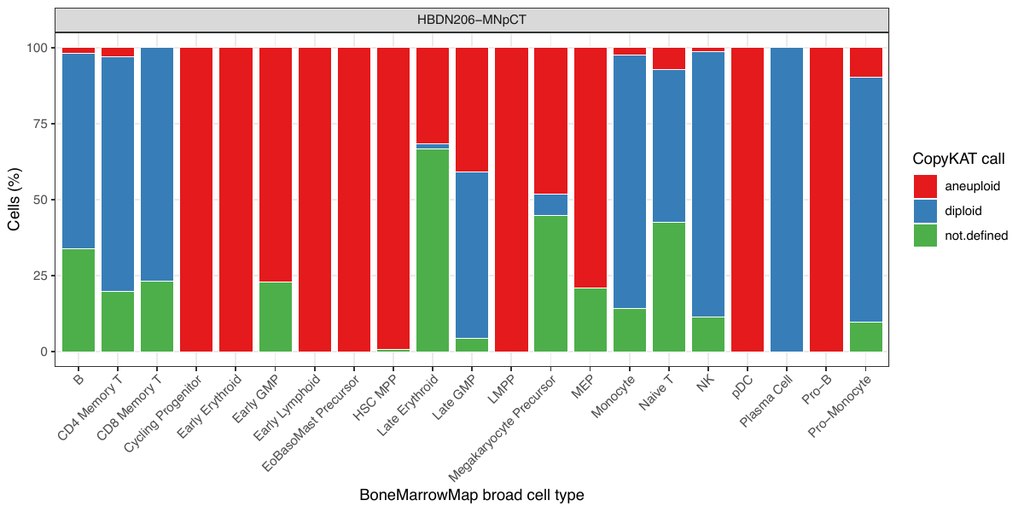

**`03a_copykat_counts_by_BoneMarrowMap_broad_celltype.pdf`**

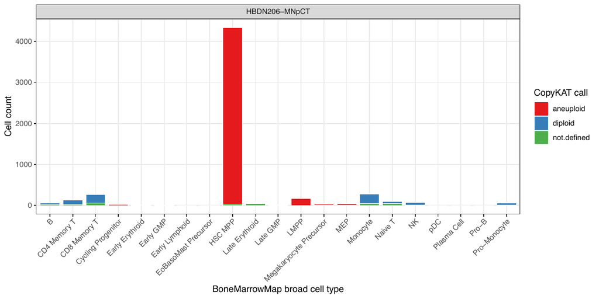

**`01_copykat_call_composition_by_sampleID.pdf`**

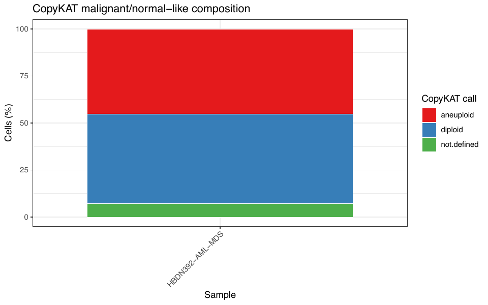

**`02_copykat_calls_on_projected_RNA_UMAP.pdf`**

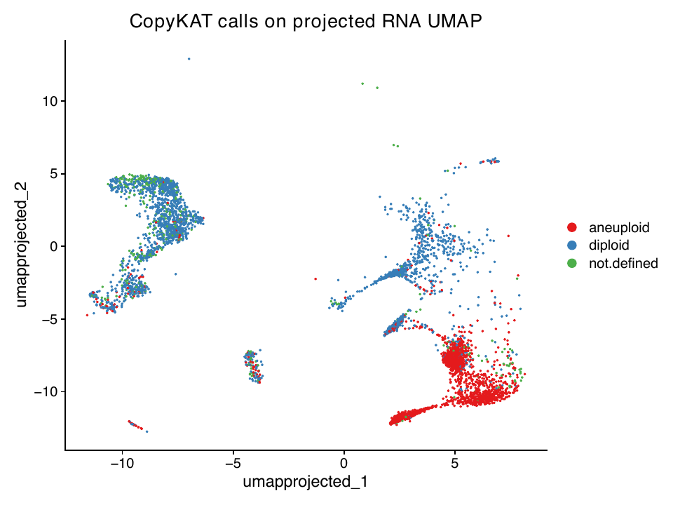

**`02a_copykat_calls_on_projected_RNA_UMAP.pdf`**

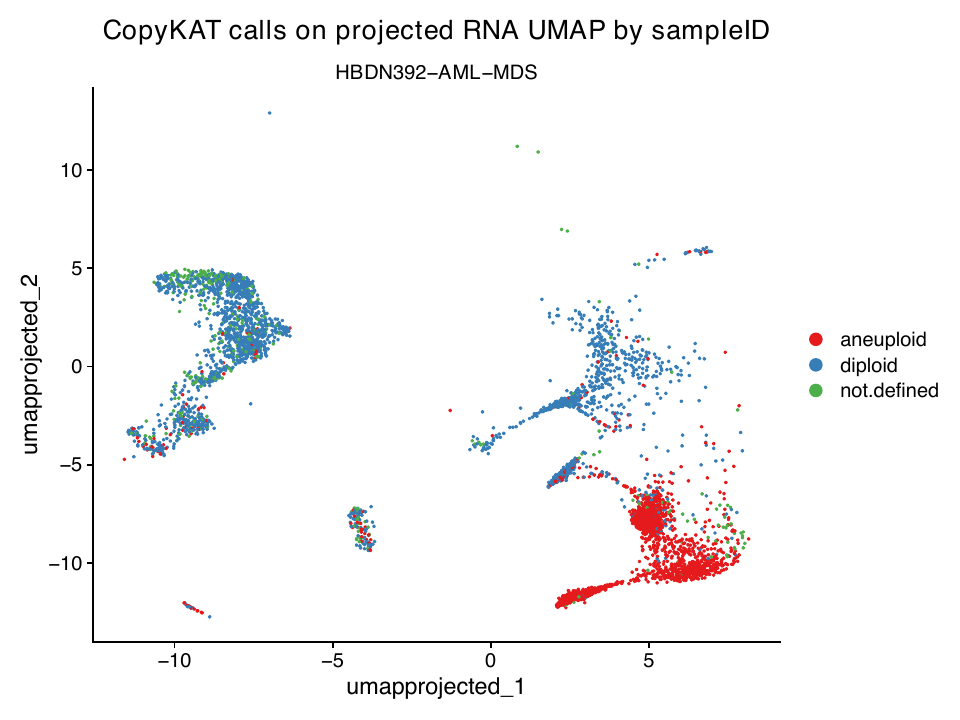

**`03_copykat_by_BoneMarrowMap_broad_celltype.pdf`**

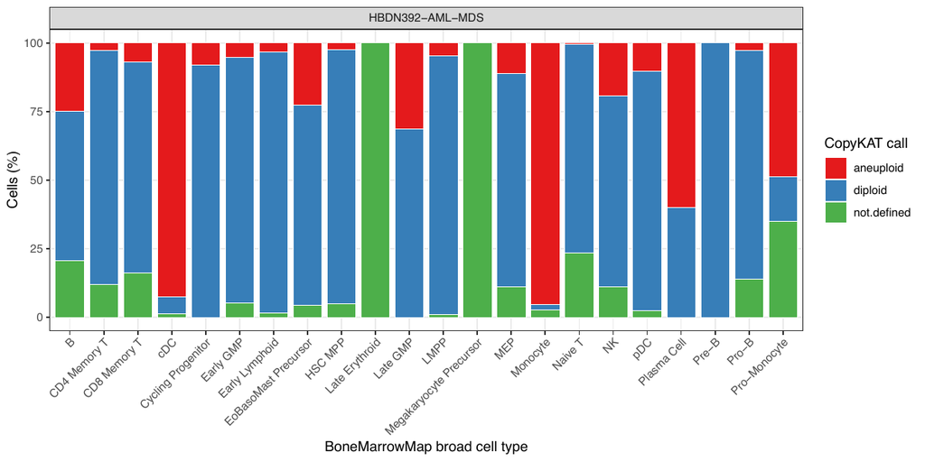

**`03a_copykat_counts_by_BoneMarrowMap_broad_celltype.pdf`**

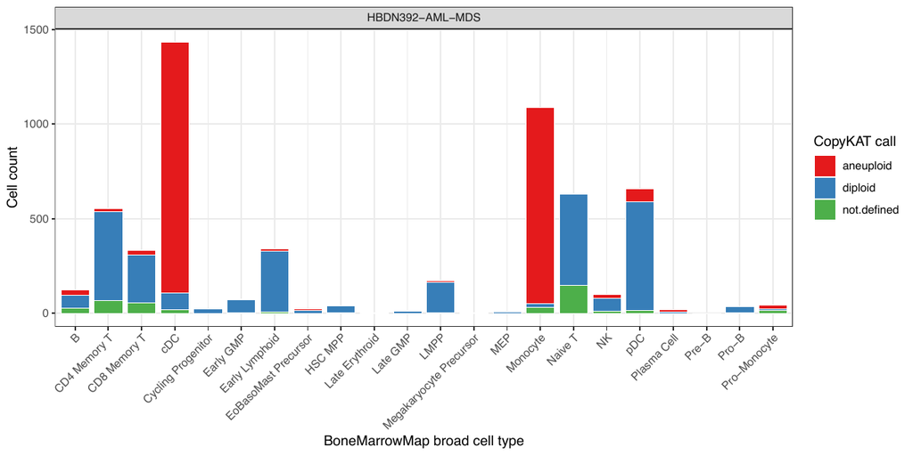

**`01_copykat_call_composition_by_sampleID.pdf`**

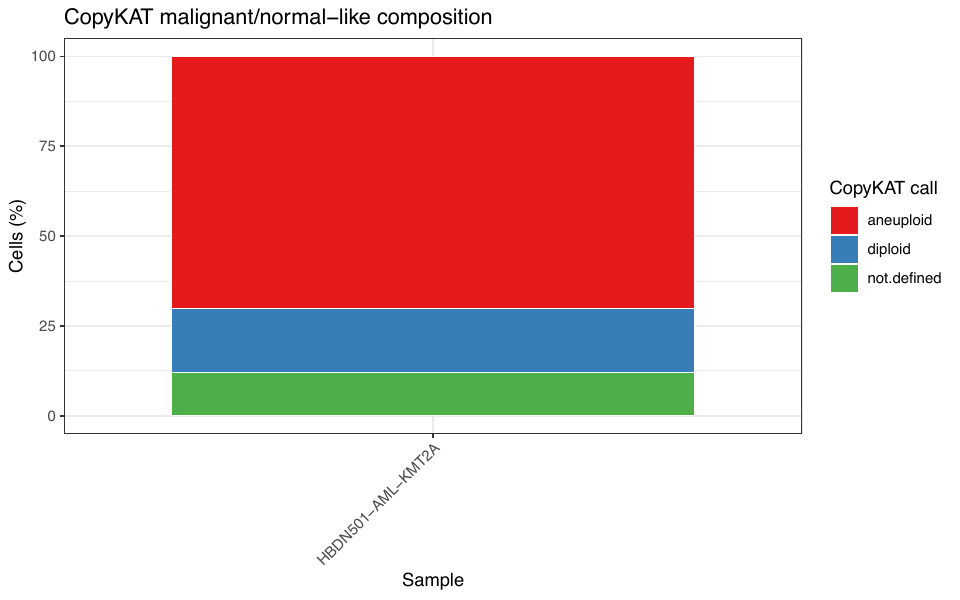

**`02_copykat_calls_on_projected_RNA_UMAP.pdf`**

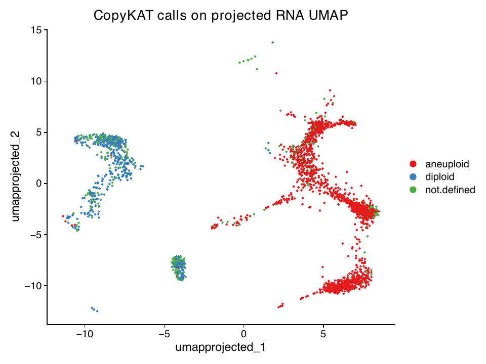

**`02a_copykat_calls_on_projected_RNA_UMAP.pdf`**

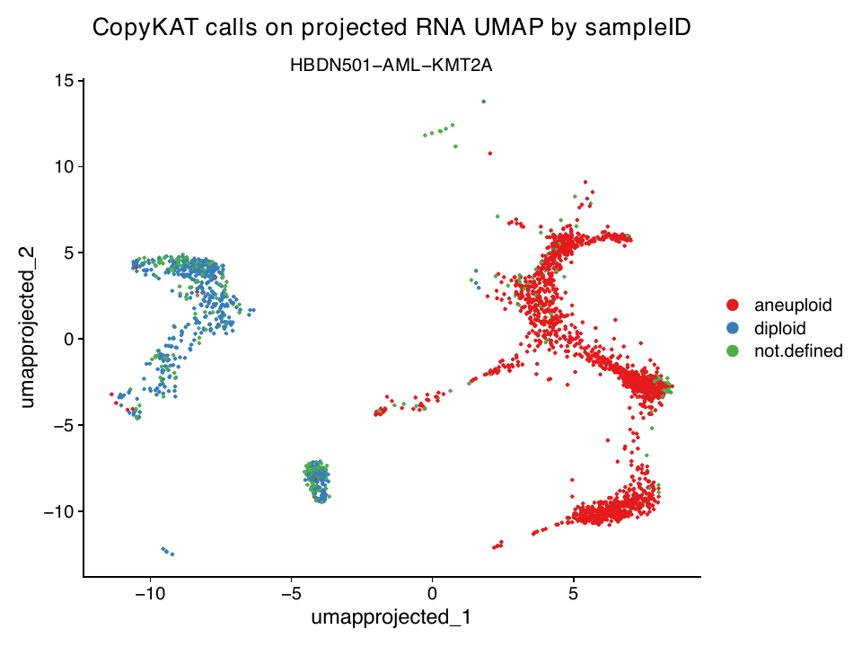

**`03_copykat_by_BoneMarrowMap_broad_celltype.pdf`**

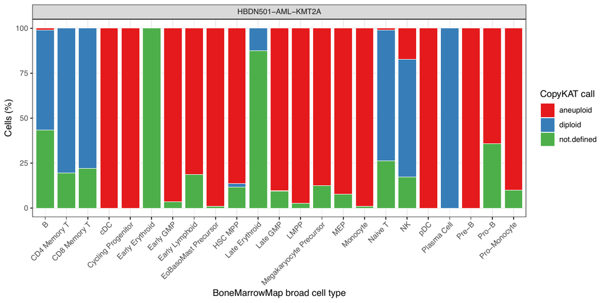

**`03a_copykat_counts_by_BoneMarrowMap_broad_celltype.pdf`**

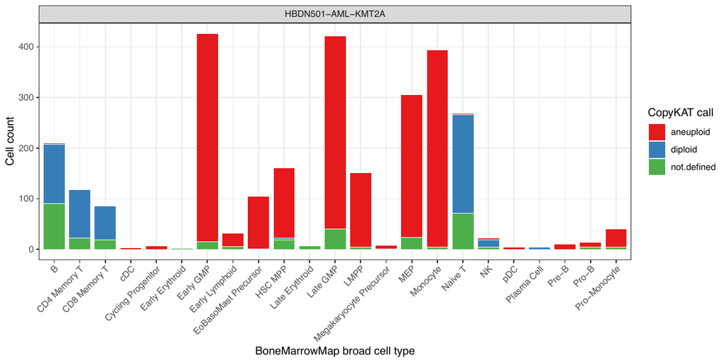

# 6. What was run

| Step | Script | What |
| --- | --- | --- |
| 01 | 01.copykat_per_donor.R | CopyKAT per donor, lymphoid cells as the confident-normal anchor. MOLM13 assigned rather than called. |
| 02 | 02.numbat_pileup_and_phase.sh | Numbat stage 1 on the cluster: pileup and phasing from the Cell Ranger BAM, in the container. |
| 03 | 03.numbat_run.sh + 03a.numbat_run.R | Numbat stage 2: CNV and clone inference, one array task per donor. |
| 04 | 04.numbat_to_seurat.R | Pulls the per-donor Numbat calls onto the annotated object and plots compartment and clone against the BoneMarrowMap annotation. |
| 05 | 05.compare_numbat_copykat.R | Numbat against CopyKAT on one donor, with the clone inspection. Donor and doublet handling are arguments. |
| 06 | 06.numbat_normal_donor_control.R | The specificity control: what Numbat reports on the healthy donor, against the three AML donors. |
| 07 | 07.compare_shortread_longread_numbat.R | Short-read against long-read Numbat on the same cells. |
| 08 | 08.cancer_calling_summary.R | Scores the callers against each other from the tables alone. |
| 09 | 09.cancer_calling_report.Rmd | This report. |

The scripts this was collated from, and what changed:

- `9.copykat.R` ran CopyKAT over the whole GEM well at once. That is wrong here, not merely superseded - the well pools four donors and CopyKAT’s baseline comes from the cells it is given, so one donor’s aneuploidy could define another’s normal. `9a.copykat_perSample.R` is the per-donor version and is what produced the surviving outputs.
- the donor loop in `9a.copykat_perSample.R` was `unique(temp$sample_name)[c(4)]`, a hardcoded index, so it did one donor per invocation with the index edited by hand between runs. It now loops over all of them.
- `9b.numbat.sh` declared `SAMPLES` twice, LK1 first and LK2 second, so the second assignment silently overrode the first and the LK1 block was dead code that looked live. It also had `set -euo pipefail` commented out, so a failure inside the container did not fail the array task and a broken donor looked finished. Both fixed, and the run is now an argument.
- `10.numbat_annotation.R` (LK2) and `13.numbat_annotation.R` (LK1) are the same script at two stages. 13 hardcodes the donor directories with two commented out, and has its `readRDS` commented out so it only ran if the object was already in the session. 10 derives the directories, records which Numbat outputs each donor actually has, and handles incomplete runs. Step 04 is 10, parameterised by run.
- `12c.compare_numbat_copykat.R`, `12c.compare_numbat_copykat_501.R` and `12d.compare_numbat_copykat_noDoublets.R` are one script run three times with the donor edited in place. The entire difference between 12c and 12d is one `scDblFinder` subset call and a different output directory name, which is now a flag.
- `12d.investigate_clones.R` is **not** a separate analysis - 326 of its 333 non-comment lines are verbatim inside `12d_noDoublets`. It is the earlier standalone version, already folded in, so step 05 covers it.
- `20a.compare_all_clone_methods.R` is deliberately out of scope: it also brings in the mitochondrial clone callers and belongs with that report.

# 7. Data locations

Tools

| What | Where |
| --- | --- |
| Annotated input, pilot | results/seurat_annotated/260423_VH01624_453_222HWMYNX/LK1_GEX_CITE_DSB_BoneMarrowMap_projected.rds |
| Annotated input, LK2 | results/seurat_annotated/260528_VH01624_464_222K7VKNX/demux_singlets_annotated_seurat.rds |
| Cell Ranger BAM (Numbat input) | results/cellranger_withbam//-GEX/outs/possorted_genome_bam.bam |
| Phased SNP panel | annotation/genome1K.phase3.SNP_AF5e2.chr1toX.hg38.sorted.vcf.gz |
| Numbat container | containers/numbat-rbase_latest.sif |
| CopyKAT output | results/seurat_annotated/260423_VH01624_453_222HWMYNX/copykat_annotated/ |
| Numbat output, pilot | results/seurat_annotated/260423_VH01624_453_222HWMYNX/numbat/LK1_/numbat_final |
| Numbat output, LK2 | results/seurat_annotated/260528_VH01624_464_222K7VKNX/numbat/LK2_/numbat_final |
| Numbat output, pipeline | results_nf/260528_VH01624_464_222K7VKNX/09c_numbat_run |
| Long-read comparison | results/longread_numbat/comparison_figures, comparison_tables |
| Benchmark tables and figures (step 08) | results/benchmarking/cancer_calling |

| Tool | Version | Use |
| --- | --- | --- |
| CopyKAT | see sessionInfo | expression-only CNV calling, per donor |
| Numbat | container `numbat-rbase_latest.sif` - unpinned `latest` tag, version not recorded | allele-aware CNV and clone inference |
| Eagle | v2.4.1, inside the Numbat container | phasing |
| Seurat | 5.4.0 | object handling and plotting |

# 8. Caveats

- steps 01-05 and 07 are the collated, cleaned versions of the scripts that produced the figures shown here; they were not re-executed for this report. Steps 06 and 08 were run fresh, which is what `Analysis finished` reflects
- the Numbat container is pinned to the `latest` tag, so the exact version that produced these results is not recorded and cannot be reconstructed from the image name. Any re-run may not reproduce them
- **Numbat completed for only two of the four pilot donors.** HBDN392-AML-MDS and MOLM13 are entirely `not_called`, so the caller comparison rests on two donors
- the CopyKAT/Numbat agreement is not an independent comparison in the lymphoid compartment, because those cells are CopyKAT’s normal anchor. It is independent in the myeloid and progenitor compartments
- **HBDN206-MNpCT is called 81% aneuploid by CopyKAT and 74% tumour by Numbat**, and its name does not carry an AML designation the way the other pilot donors’ do. Either it is a malignant sample that is simply not named as one, or both callers are failing on it in the same way. Nothing here settles which, and it should be checked against the sample sheet before these fractions are quoted
- the long-read comparison covers three LK2 donors only, and the donorN directories in the long-read output are positional - the mapping to sample names is an assumption, now asserted in step 07 rather than trusted silently
- step 06 reads the pipeline Numbat output under `results_nf/`, not the standalone output the other steps use. They are separate runs and their numbers are not interchangeable